# Lab 14 - Regularized Regression

This is a short lab covering the topic of regularization in the context of regression models.

```python
import pandas as pd
import numpy as np
import matplotlib.pyplot as plt
import sklearn
import math
```

In our *regression* examples, we'll use the [superconductivity dataset from the UCI machine learning repository](https://archive.ics.uci.edu/ml/datasets/Superconductivty+Data):

```python
### Read superconductivity data
sc = pd.read_csv("https://remiller1450.github.io/data/super.csv")

## Train-test split
from sklearn.model_selection import train_test_split
train_sc, test_sc = train_test_split(sc, test_size=0.2, random_state=5)

## Split predictors and outcome
train_y_sc = train_sc['critical_temp']
train_X_sc = train_sc.drop(['critical_temp'], axis=1)
train_X_sc.shape
```

```
(17010, 81)
```

For some additional background, *critical temperature* is the temperature at which the electrical resistivity of a material vanishes. For most conductors, resistivity gradually declines with temperature, but for superconductors it drops abruptly. The 81 predictors in this application are characteristics derived from the chemical formulas of various materials. We will aim to predict critical temperature using the chemical features of a material.

In our *classification* examples, we'll return to the data from Sobar (2016) that has been used in several of our previous labs. Recall that this study aimed to accurately predict instances of cervix cancer using data from several non-invasive behavioral questionaires.

```python
## Read sobar data
sobar = pd.read_csv('https://archive.ics.uci.edu/ml/machine-learning-databases/00537/sobar-72.csv')
train_sobar, test_sobar = train_test_split(sobar, test_size=0.2, random_state=5)

## Define outcome variable
train_sobar_y = train_sobar['ca_cervix']

## Define predictor matrix
train_sobar_X = train_sobar.drop('ca_cervix',axis=1)
```

## Part 1 - Ridge and Lasso penalties for linear regression

Regularization is penalty imposed on a model's estimated weights that skrinks them towards zero. For ridge regression, the penalty function has the basic form: $\alpha \sum w_j^2$, while the Lasso penalty function is: $\alpha \sum |w_j|$.

Ridge and Lassso regression each have their own functions in `sklearn`, and both functions are similar to `LinearRegression` with an additional argument, `alpha`, that controls the amount of regularization. However, it is unwise jump straight into a cross-validated grid search to tune $\alpha$ using `GridSearchCV()` like we've done for other tuning parameters. To understand why, let's first look at a **regularization path plot** for a Lasso model:

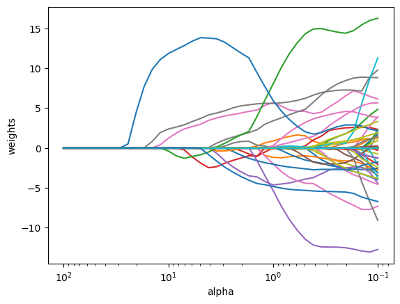

```python
from sklearn.linear_model import Ridge
from sklearn.linear_model import Lasso
from sklearn.preprocessing import StandardScaler

## Standardize
train_Xs_sc = StandardScaler().fit_transform(train_X_sc)

## Set up sequence of alphas
n_alphas = 40
alphas = np.logspace(-1, 2, n_alphas)

## Find coefficients at each alpha (Ridge regression)
coefs = []
for a in alphas:
    lasso_mod = Lasso(alpha=a)
    lasso_mod.fit(train_Xs_sc, train_y_sc)
    coefs.append(lasso_mod.coef_)

## Create Plot
ax = plt.gca()
ax.plot(alphas, coefs)
ax.set_xscale("log")
ax.set_xlim(ax.get_xlim()[::-1])  # reverse axis
plt.xlabel("alpha")
plt.ylabel("weights")
plt.axis("tight")
plt.show()
```

Notice that for a given value of `alpha`, the weight estimates at nearby values of `alpha` are very similar (ie: the regularization path is smooth).

Thus, for computational efficiency, we don't want to perform a large number of optimization calculations that start "from scratch". Instead, it's more efficient (and numerically stable) to use a "warm start" strategy that finds weight estimates for the current value of `alpha` starting with the estimates from a slightly larger `alpha` the initial value guess. The specialized functions `RidgeCV()` and `LassoCV()` use warm starts to facilitate easier tuning `alpha`:

```python
from sklearn.linear_model import RidgeCV

## Set up sequence of alphas
n_alphas = 200
alphas = np.logspace(-1, 5, n_alphas)

## Evaluate using 5-fold CV and print the best alpha
ridge_cv_res = RidgeCV(cv=5, alphas = alphas, scoring='neg_mean_squared_error').fit(train_Xs_sc, train_y_sc)
best_alpha = ridge_cv_res.alpha_
print(best_alpha)
```

```
0.11489510001873092
```

**Question 1**:

- **Part A**: Use the `LassoCV()` function with k=5 folds to find the value of $\alpha$ that leads to the best cross-validated performance on the superconductivity training data. Because `LassoCV()` does not currently support alternative scoring functions, you may use the default ($R^2$).
- **Part B**: Use a pipeline and cross-validated grid-search approach to determine if your Lasso model from part A performs better than a Ridge regression model $\alpha = 0.115$ (the best alpha found above), and better than an ordinary linear regression model. Use 'neg_mean_squared_error' as the scoring metric for this comparison.
- **Part C**: Create a regularization path plot for Ridge regression and qualitatively compare it versus the Lasso regularization path plot that was given.

## Part 2 - Ridge and Lasso penalties for logistic/softmax regression

In our previous lab, we used the argument `penalty=None` (or `penalty='none'`) whenever fitting a logistic (or softmax) regression model. This was because these functions are programmed to include a ridge penalty by default.

In the `LogisticRegression()` function, the argument `C` is the *inverse* of the regularization strength. So smaller values of `C` correspond with higher amounts of penalization (the opposite of how $\alpha$ works in the `Ridge` and `Lasso` functions we've used for numeric outcomes).

Below we demonstrate L1 regularized logistic regression on the Sobar data:

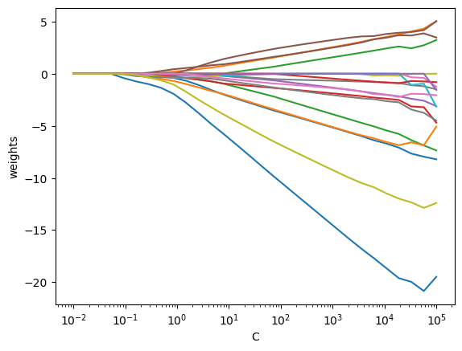

```python
from sklearn.linear_model import LogisticRegression

## Standardize X
train_sobar_Xs = StandardScaler().fit_transform(train_sobar_X)

## Set up sequence of "C" values
n_c = 30
c_vals = np.logspace(-2, 5, n_c)

## Initialize model
lr_mod = LogisticRegression(penalty="l1", solver="liblinear", warm_start=True, tol=1e-6)

coefs = []
for c in c_vals:
    lr_mod.set_params(C=c)
    lr_mod.fit(train_sobar_Xs, train_sobar_y)
    coefs.append(lr_mod.coef_.ravel())


## Create Plot
ax = plt.gca()
ax.plot(c_vals, coefs)
ax.set_xscale("log")
plt.xlabel("C")
plt.ylabel("weights")
plt.axis("tight")
plt.show()
```

Notice how we changed the optimization algorithm to `liblinear`, an algorithm that supports both Lasso and Ridge penalties (the default algorithm, `lbfgs`, only supports L2 regularization). The documentation page for `LogisticRegression()` provides information on the solving algorithms that are compatible with each penalty.

Additionally, I needed to increase the tolerance of the solving algorithm (using the `tol` parameter) to achieve converge for some of the smaller amounts of penalization (ie: large values of `C`). We can start to see signs of this estimation instability in the weight estimates towards the end of the regularization path.

If we wanted to use the Ridge penalty (L2 regularization) instead of the Lasso penalty (L1 regularization), we'd simply modify the `penalty` argument:

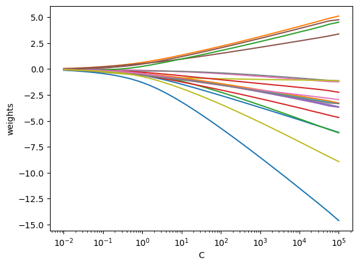

```python
## Set up sequence of "C" values
n_c = 30
c_vals = np.logspace(-2, 5, n_c)

## Initialize model
lr_mod = LogisticRegression(penalty="l2", solver="liblinear", warm_start=True, tol=1e-6)

coefs = []
for c in c_vals:
    lr_mod.set_params(C=c)
    lr_mod.fit(train_sobar_Xs, train_sobar_y)
    coefs.append(lr_mod.coef_.ravel())


## Create Plot
ax = plt.gca()
ax.plot(c_vals, coefs)
ax.set_xscale("log")
plt.xlabel("C")
plt.ylabel("weights")
plt.axis("tight")
plt.show()
```

When choosing between regularization approaches, it is important to remember that L1 regularization promotes *sparsity* (weight estimates of exactly zero), while L2 regularization does not. However, L2 regularization can provide greater stability in the face of highly collinear predictors.

To use cross-validation to tune the hyperparameter, `C`, we should rely upon the `LogisticRegressionCV()` function. As discussed in the previous section, this specialized function uses the "warm start" strategy and is much more effective at tuning `C` than `GridSearchCV()`.

```python
from sklearn.linear_model import LogisticRegressionCV

## Set up seq of C values
n_c = 30
c_vals = np.logspace(-2, 5, n_c)

## Initialize and fit
cv_lr_mod = LogisticRegressionCV(cv=10, Cs = c_vals, penalty="l1", solver="liblinear",
                                 tol=1e-6, scoring = "f1").fit(train_sobar_Xs, train_sobar_y)

## Print the best value of C
print(cv_lr_mod.C_)

## Print the cross-validated score
print(cv_lr_mod.score(train_sobar_Xs, train_sobar_y))
```

```
[4.52035366]
1.0
```

In this example we provided a sequence of `C` values via the `Cs` argument. We then access the single value of `C` that resulted in the best cross-validated score using the `.C_` attribute of our fitted model.

**Question 2**

- **Part A**: Modify the example code in this section to find an L2 regularized logistic regression that uses an optimal amount of regularization as determined by the model's cross-validated F1 score.
- **Part B**: Construct an ROC curve using cross-validated estimates of the probability of cervix cancer found using the best model from Part A.

## Part 3 - Elastic Net

The Lasso penalty has the benefit of leading to sparse models; however, its behavior in scenarios with highly collinear predictors can be undesirable. Recall that if two predictors are very highly correlated, the Lasso penalty will select one of them and combined signal (impact on the outcome variable) will be absorbed into this single estimated weight. In these situations, introducing additional L2 regularization on top of the Lasso penalty can lead to both predictors being selected, and their shared signal being split between them (perhaps resulting in a more generalizable model).

> Similar to the lasso, the elastic net simultaneously does automatic variable selection and continuous shrinkage, and it can select groups of correlated variables. It is like a stretchable fishing net that retains ‘all the big fish’.

In `sklearn`, Elastic Net models use a common $\alpha$ value and the argument `l1_ratio` to control the proportion of that value used in the L1 penalty (with the remainder being used as the L2 penalty parameter). For example, `l1_ratio = 1` is equivalent to the Lasso penalty, while `l1_ratio = 0` is equivalent to the ridge penalty.

Similar to other regularized regression methods, elastic net has it's own built-in cross-validation that we can use to tune the parameters `l1_ratio` and `alpha` before going on to include an elastic net model in a larger comparison of different models.

```python
from sklearn.linear_model import ElasticNetCV

## Set up sequence of alphas
n_alphas = 50
alphas = np.logspace(-1, 5, n_alphas)

## Set up a few differ l1 ratios
rats = [.1, .5, .7, .9, .95, .99, 1]

## Evaluate using 5-fold CV and print the best alpha
enet_cv_res = ElasticNetCV(cv=5, alphas = alphas, l1_ratio = rats).fit(train_Xs_sc, train_y_sc)
print([enet_cv_res.alpha_, enet_cv_res.l1_ratio_])
```

```
[0.1, 1.0]
```

Note that once `ElasticNetCV` has found the best performing combination of `alpha` and `l1_ratio` via cross-validation it will fit the corresponding model to the entire data set. Thus, printing the `alpha_` and `l1_ratio_` attributes of the fitted model tells us the best combination of tuning parameters.

In this example, we see that a Lasso model (`l1_ratio = 1.0`) with `alpha=0.1` was found to be optimal.

If we'd like to use elastic net regularization for classification, we simply need to change the `penalty` argument in `LogisticRegression()` (or `LogisticRegressionCV()`) to "elasticnet". When doing this, we must be careful to adjust the optimization algorithm that is used, as "saga" is currently the only solver that supports the elastic net penalty.

```python
## Set up seq of C values
n_c = 30
c_vals = np.logspace(-2, 5, n_c)

## Fit
cv_elastic_lr = LogisticRegressionCV(cv=10, Cs = c_vals,
                                     l1_ratios = [0.1,0.5],
                                     penalty="elasticnet",solver="saga", tol=1e-4, max_iter = 1000,
                                     scoring = "f1").fit(train_sobar_Xs, train_sobar_y)

## Print the best value of C
print(cv_elastic_lr.C_)

## Print the best l1_ratio
print(cv_elastic_lr.l1_ratio_)

## Print the cross-validated score
print(cv_lr_mod.score(train_sobar_Xs, train_sobar_y))
```

```
[72.78953844]
[0.1]
1.0
```

It's worth noting that the tolerance, `tol`, and maximum number of iterations, `max_iter`, were both changed from their defaults in order to reach convergence for these data (and the tuning parameters used).

In case you aren't familiar with these terms, tolerance reflects maximum change in weights that is acceptable for the estimates to be considered optimized. For example, setting `tol=1e-4` indicates that if the largest change in weight estimates from iteration to the next is less than 0.0001 the algorithm has reached a sufficiently accurate solution.

**Question #3**

- **Part A**: Modify the example code shown above (that fits a cross-validated elastic net model to the "sobar" data) to consider lasso and ridge penalties in addition to the elastic net penalty. *Hint*: all you need to do is adjust the input to `l1_ratios` achieve this). Report the best fitting model and state whether it uses the elastic net, lasso, or ridge penalty.